# 因子

# 目录

- 介绍
  - 1.1 前提准备
- 2 创建因子
- 3 社会调查案例
- 4 改变因子水平值的顺序
- 5 更改因子的水平值

# 1 介绍

在 `R` 中，因子用来表示类别变量，这类变量有已知的水平值 `levels` 。由于很多时候，处理因子比字符更加容易，所以 `R` 中的很多函数会自动将字符转换为因子。这种特性有些时候会产生错误。但是在 `tidyverse` 中，不用担心会发生这种情况。  
更多关于因子的历史由来，参见 [stringsAsFactors: An unauthorized biography](http://simplystatistics.org/2015/07/24/stringsasfactors-an-unauthorized-biography/) 和 [stringsAsFactors =](http://notstatschat.tumblr.com/post/124987394001/stringsasfactors-sigh) 。

## 1.1 前提准备

```r
library(tidyverse)
```

```r
library(forcats)
```

# 2 创建因子

假设有一个记录月份的变量：

```r
x1 <- c("Dec", "Apr", "Jan", "Mar")
```

使用字符串来记录变量，会存在以下两个问题：

- 月份仅仅有12个可能的取值，但是输入变量时非常繁琐：

```r
x2 <- c("Dec", "Apr", "Jam", "Mar")
```

- 排序按照字母顺序，没有现实意义：

```r
sort(x1)
```

```
[1] "Apr" "Dec" "Jan" "Mar"
```

通过因子可以解决以上问题。

- 首先创建水平值 `levels` ：

```r
month_levels <- c(
  "Jan", "Feb", "Mar", "Apr", "May", "Jun",
  "Jul", "Aug", "Sep", "Oct", "Nov", "Dec"
)
```

- 然后创建因子：

```r
y1 <- factor(x1, levels = month_levels)
y1
```

```
[1] Dec Apr Jan Mar
Levels: Jan Feb Mar Apr May Jun Jul Aug Sep Oct Nov Dec
```

因子会按照水平值的排序来进行排序：

```r
sort(y1)
```

```
[1] Jan Mar Apr Dec
Levels: Jan Feb Mar Apr May Jun Jul Aug Sep Oct Nov Dec
```

在创建因子时，不在 `levels` 中的值会被转化为 `NA` ：

```r
y2 <- factor(x2, levels = month_levels)
y2
```

```
[1] Dec  Apr  <NA> Mar
Levels: Jan Feb Mar Apr May Jun Jul Aug Sep Oct Nov Dec
```

`readr::parse_factor()` 函数在遇到不在 `levels` 中的值时会报错：

```r
y2 <- parse_factor(x2, levels = month_levels)
```

```
1 parsing failure.
row col           expected actual
  3  -- value in level set    Jam
```

如果没有创建 `levels` ，则根据输入的数据自动创建 `levels` ，并以首字母顺序排列：

```r
factor(x1)
```

```
[1] Dec Apr Jan Mar
Levels: Apr Dec Jan Mar
```

用数据中元素出现的顺序来自动创建 `levels` ：

- `unique(x)`

```r
f1 <- factor(x1, levels = unique(x1))
f1
```

```
[1] Dec Apr Jan Mar
Levels: Dec Apr Jan Mar
```

- `fct_inorder()`

```r
f2 <- x1 %>% factor() %>% fct_inorder()
f2
```

```
[1] Dec Apr Jan Mar
Levels: Dec Apr Jan Mar
```

`levels()` 函数可以直接从数据中创建水平值 `levels` ：

```r
levels(f2)
```

```
[1] "Dec" "Apr" "Jan" "Mar"
```

# 3 社会调查案例

`forcats::gss_cat` 是从一项在美国开展的长期社会调查中收集的数据，下面用该数据集展示如何操作因子。

```r
gss_cat
```

| year | marital | age | race | rincome | partyid | relig | denom | tvhours |
| --- | --- | --- | --- | --- | --- | --- | --- | --- |
| 2000 | Never married | 26 | White | $8000 to 9999 | Ind,near rep | Protestant | Southern baptist | 12 |
| 2000 | Divorced | 48 | White | $8000 to 9999 | Not str republican | Protestant | Baptist-dk which | NA |
| 2000 | Widowed | 67 | White | Not applicable | Independent | Protestant | No denomination | 2 |
| 2000 | Never married | 39 | White | Not applicable | Ind,near rep | Orthodox-christian | Not applicable | 4 |
| 2000 | Divorced | 25 | White | Not applicable | Not str democrat | None | Not applicable | 1 |
| 2000 | Married | 25 | White | $20000 - 24999 | Strong democrat | Protestant | Southern baptist | NA |
| 2000 | Never married | 36 | White | $25000 or more | Not str republican | Christian | Not applicable | 3 |
| 2000 | Divorced | 44 | White | $7000 to 7999 | Ind,near dem | Protestant | Lutheran-mo synod | NA |
| 2000 | Married | 44 | White | $25000 or more | Not str democrat | Protestant | Other | 0 |
| 2000 | Married | 47 | White | $25000 or more | Strong republican | Protestant | Southern baptist | 3 |

[output cut: 990 more lines]

```
#> # A tibble: 21,483 × 9
#>    year       marital   age   race        rincome            partyid
#>   <int>        <fctr> <int> <fctr>         <fctr>             <fctr>
#> 1  2000 Never married    26  White  $8000 to 9999       Ind,near rep
#> 2  2000      Divorced    48  White  $8000 to 9999 Not str republican
#> 3  2000       Widowed    67  White Not applicable        Independent
#> 4  2000 Never married    39  White Not applicable       Ind,near rep
#> 5  2000      Divorced    25  White Not applicable   Not str democrat
#> 6  2000       Married    25  White $20000 - 24999    Strong democrat
#> # ... with 2.148e+04 more rows, and 3 more variables: relig <fctr>,
#> #   denom <fctr>, tvhours <int>
```

可以用以下方法查看因子的水平：

`count()` 只会显示出现过的水平：

```r
gss_cat %>%
  count(race)
```

| race | n |
| --- | --- |
| Other | 1959 |
| Black | 3129 |
| White | 16395 |

```
#> # A tibble: 3 × 2
#>     race     n
#>   <fctr> <int>
#> 1  Other  1959
#> 2  Black  3129
#> 3  White 16395
```

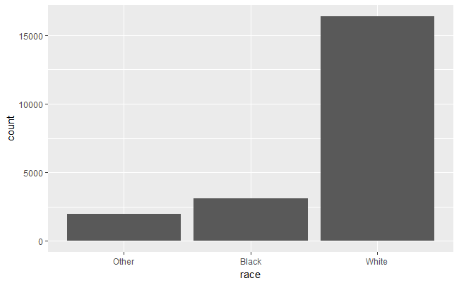

```r
ggplot(gss_cat, aes(race)) +
  geom_bar()
```

默认情况下， `ggplot2` 会丢弃没有出现过的水平，通过设置参数 `scale_x_discrete(drop = FALSE)` 可以改变这一特性：

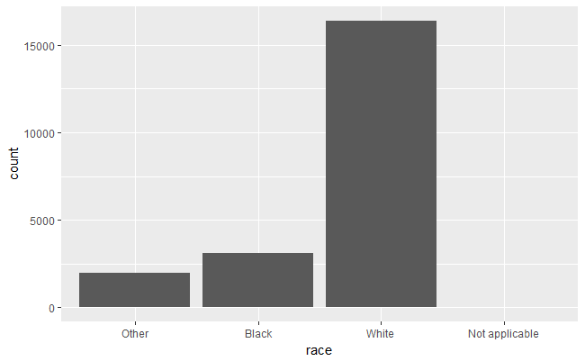

```r
ggplot(gss_cat, aes(race)) +
  geom_bar() +
  scale_x_discrete(drop = FALSE)
```

# 4 改变因子水平值的顺序

- `fct_reorder()` 可以改变因子水平值的排序，也可以用于 `aes()` 和 `mutate()` 中：

可视化不同宗教的人群平均每天看电视的时间：

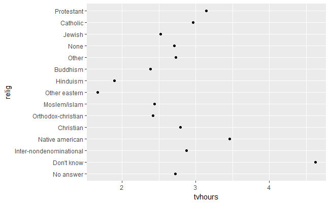

```r
relig <- gss_cat %>%
  group_by(relig) %>%
  summarise(
    age = mean(age, na.rm = TRUE),
    tvhours = mean(tvhours, na.rm = TRUE),
    n = n()
  )
ggplot(relig, aes(tvhours, relig)) + geom_point()
```

上图显得杂乱无章，可以使用 `fct_reorder()` 函数对 `relig` 进行排序。

- `fct_reorder()` 函数接受以下3个参数：
  - `f` ：需要改变水平值排序的因子
  - `x` ：作为改变水平值排序依据的数值向量
  - `fun` ：可选，如果每一个 `f` 的水平，都对应数个 `x` 的值，则使用 `fun` ，默认为 `median` 。

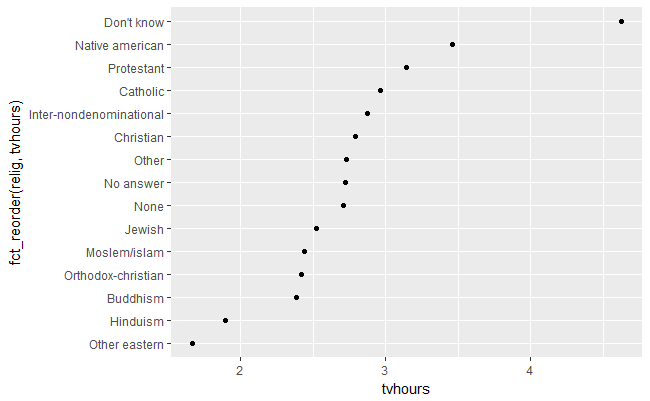

```r
ggplot(relig, aes(tvhours, fct_reorder(relig, tvhours))) +
  geom_point()
```

将 `fct_reorder()` 移出 `aes()` ，放进 `mutate()` 中，可以起到同样的效果：

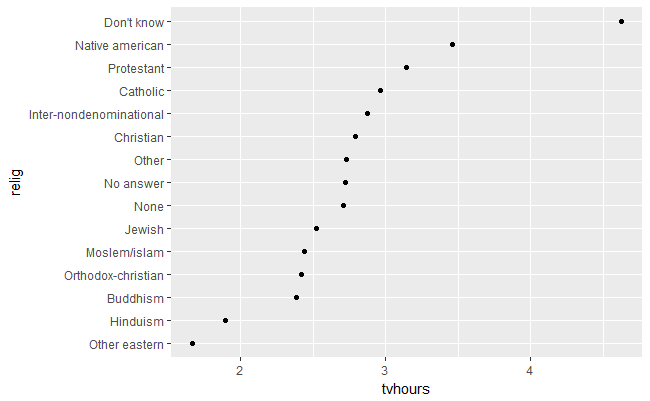

```r
relig %>%
  mutate(relig = fct_reorder(relig, tvhours)) %>%
  ggplot(aes(tvhours, relig)) +
    geom_point()
```

可视化不同收入群体的平均年龄，并依年龄对收入分组排序：

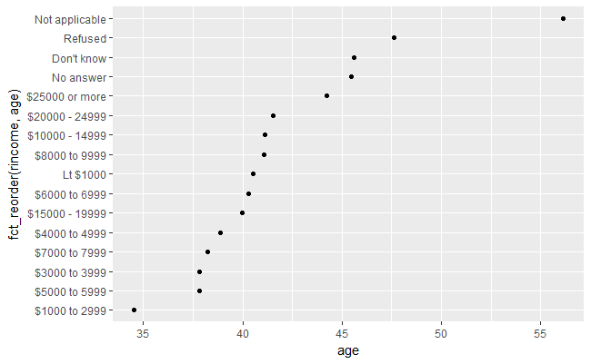

```r
rincome <- gss_cat %>%
  group_by(rincome) %>%
  summarise(
    age = mean(age, na.rm = TRUE),
    tvhours = mean(tvhours, na.rm = TRUE),
    n = n()
  )
ggplot(rincome, aes(age, fct_reorder(rincome, age))) + geom_point()
```

此处，对收入分组因子重新排序并不是个好主意，因为收入分组本身的排序是有意义的。因此， `fct_reorder()` 适用于对无序的因子进行重排序：

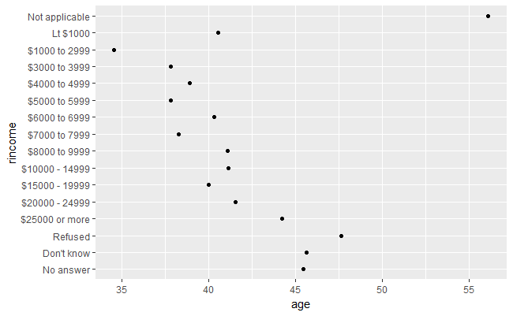

```r
rincome <- gss_cat %>%
  group_by(rincome) %>%
  summarise(
    age = mean(age, na.rm = TRUE),
    tvhours = mean(tvhours, na.rm = TRUE),
    n = n()
  )
ggplot(rincome, aes(age, rincome)) + geom_point()
```

- `fct_relevel()` 可以将因子中的某个水平值放到最前面，将 “Not applicable” 放到水平的最前面：

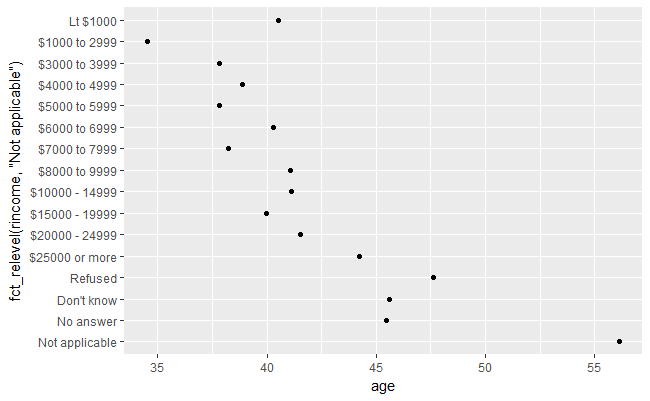

```r
ggplot(rincome, aes(age, fct_relevel(rincome, "Not applicable"))) +
  geom_point()
```

- `fct_reorder2()` 用最大 `x` 情况下 `y` 的取值来对 `f` 进行排序：

```r
by_age <- gss_cat %>%
  filter(!is.na(age)) %>%
  group_by(age, marital) %>%
  count() %>%
  mutate(prop = n / sum(n))
by_age
```

| age | marital | n | prop |
| --- | --- | --- | --- |
| 18 | Never married | 89 | 0.978021978 |
| 18 | Married | 2 | 0.021978022 |
| 19 | Never married | 234 | 0.939759036 |
| 19 | Divorced | 3 | 0.012048193 |
| 19 | Widowed | 1 | 0.004016064 |
| 19 | Married | 11 | 0.044176707 |
| 20 | Never married | 227 | 0.904382470 |
| 20 | Separated | 1 | 0.003984064 |
| 20 | Divorced | 2 | 0.007968127 |
| 20 | Married | 21 | 0.083665339 |

[output cut: 341 more lines]

```
#> Source: local data frame [351 x 4]
#> Groups: age [72]
#>
#>      age       marital     n        prop
#>    <int>        <fctr> <int>       <dbl>
#> 1     18 Never married    89 0.978021978
#> 2     18       Married     2 0.021978022
#> 3     19 Never married   234 0.939759036
#> 4     19      Divorced     3 0.012048193
#> 5     19       Widowed     1 0.004016064
#> 6     19       Married    11 0.044176707
#> 7     20 Never married   227 0.904382470
#> 8     20     Separated     1 0.003984064
#> 9     20      Divorced     2 0.007968127
#> 10    20       Married    21 0.083665339
#> # ... with 341 more rows
```

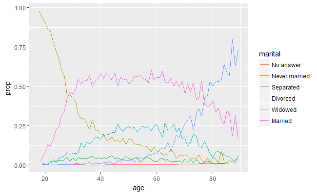

```r
ggplot(by_age, aes(age, prop, colour = marital)) +
  geom_line(na.rm = TRUE)
```

按照最大 `age` (89岁）下的 `prop` 的取值，从高到低来对 `martial` 因子的水平值进行排序

```r
by_age %>%
  select(age, marital, prop) %>%
  spread(marital, prop) %>%
  arrange(desc(age))
```

| age | No answer | Never married | Separated | Divorced | Widowed | Married |
| --- | --- | --- | --- | --- | --- | --- |
| 89 | NA | 0.04054054 | NA | 0.060810811 | 0.729729730 | 0.16891892 |
| 88 | NA | 0.03508772 | NA | 0.017543860 | 0.631578947 | 0.31578947 |
| 87 | NA | 0.01851852 | NA | NA | 0.796296296 | 0.18518519 |
| 86 | 0.013513514 | 0.02702703 | 0.013513514 | 0.054054054 | 0.567567568 | 0.32432432 |
| 85 | NA | 0.01333333 | NA | 0.053333333 | 0.586666667 | 0.34666667 |
| 84 | NA | 0.03000000 | NA | 0.070000000 | 0.640000000 | 0.26000000 |
| 83 | NA | 0.09090909 | 0.010101010 | 0.070707071 | 0.535353535 | 0.29292929 |
| 82 | NA | 0.00952381 | 0.009523810 | 0.085714286 | 0.533333333 | 0.36190476 |
| 81 | NA | 0.04201681 | 0.008403361 | 0.084033613 | 0.529411765 | 0.33613445 |
| 80 | NA | 0.03937008 | NA | 0.047244094 | 0.503937008 | 0.40944882 |

[output cut: 62 more lines]

```
#> Source: local data frame [72 x 7]
#> Groups: age [72]
#>
#>      age `No answer` `Never married`   Separated   Divorced   Widowed   Married
#>    <int>       <dbl>           <dbl>       <dbl>      <dbl>     <dbl>     <dbl>
#> 1     89          NA      0.04054054          NA 0.06081081 0.7297297 0.1689189
#> 2     88          NA      0.03508772          NA 0.01754386 0.6315789 0.3157895
#> 3     87          NA      0.01851852          NA         NA 0.7962963 0.1851852
#> 4     86  0.01351351      0.02702703 0.013513514 0.05405405 0.5675676 0.3243243
#> 5     85          NA      0.01333333          NA 0.05333333 0.5866667 0.3466667
#> 6     84          NA      0.03000000          NA 0.07000000 0.6400000 0.2600000
#> 7     83          NA      0.09090909 0.010101010 0.07070707 0.5353535 0.2929293
#> 8     82          NA      0.00952381 0.009523810 0.08571429 0.5333333 0.3619048
#> 9     81          NA      0.04201681 0.008403361 0.08403361 0.5294118 0.3361345
#> 10    80          NA      0.03937008          NA 0.04724409 0.5039370 0.4094488
#> # ... with 62 more rows
```

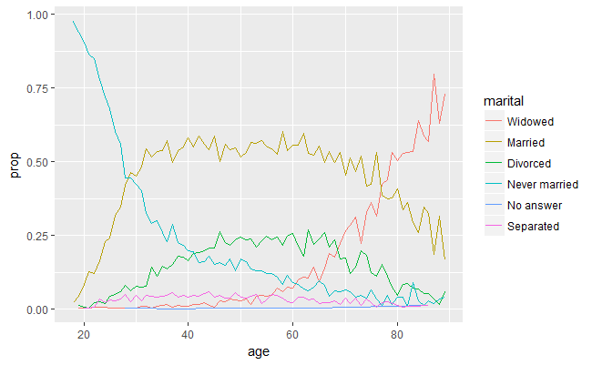

```r
ggplot(by_age, aes(age, prop, colour = fct_reorder2(marital, age, prop))) +
  geom_line() +
  labs(colour = "marital")
```

- `fct_infreq()` 用出现的频数，按降序对因子的水平值进行排序：

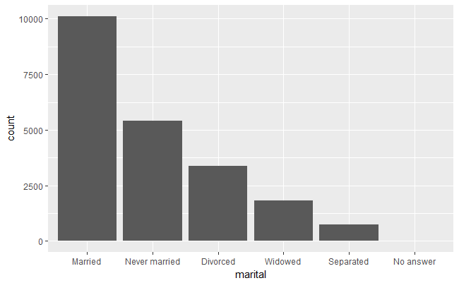

```r
gss_cat %>%
  mutate(marital = marital %>% fct_infreq()) %>%
  ggplot(aes(marital)) +
    geom_bar()
```

- `fct_rev()` 翻转因子水平值的排序：

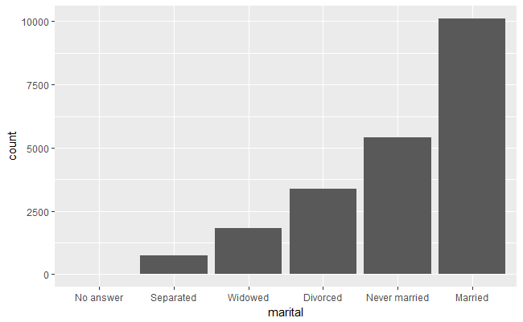

```r
gss_cat %>%
  mutate(marital = marital %>% fct_infreq() %>% fct_rev()) %>%
  ggplot(aes(marital)) +
    geom_bar()
```

# 5 更改因子的水平值

- `fct_recode()` 可以更改因子的水平值

```r
gss_cat %>% count(partyid)
```

| partyid | n |
| --- | --- |
| No answer | 154 |
| Don't know | 1 |
| Other party | 393 |
| Strong republican | 2314 |
| Not str republican | 3032 |
| Ind,near rep | 1791 |
| Independent | 4119 |
| Ind,near dem | 2499 |
| Not str democrat | 3690 |
| Strong democrat | 3490 |

```
#> # A tibble: 10 × 2
#>              partyid     n
#>               <fctr> <int>
#> 1          No answer   154
#> 2         Don't know     1
#> 3        Other party   393
#> 4  Strong republican  2314
#> 5 Not str republican  3032
#> 6       Ind,near rep  1791
#> # ... with 4 more rows
```

用 `fct_recode()` 重新修改水平值：

```r
gss_cat %>%
  mutate(partyid = fct_recode(partyid,
    "Republican, strong"    = "Strong republican",
    "Republican, weak"      = "Not str republican",
    "Independent, near rep" = "Ind,near rep",
    "Independent, near dem" = "Ind,near dem",
    "Democrat, weak"        = "Not str democrat",
    "Democrat, strong"      = "Strong democrat"
  )) %>%
  count(partyid)
```

| partyid | n |
| --- | --- |
| No answer | 154 |
| Don't know | 1 |
| Other party | 393 |
| Republican, strong | 2314 |
| Republican, weak | 3032 |
| Independent, near rep | 1791 |
| Independent | 4119 |
| Independent, near dem | 2499 |
| Democrat, weak | 3690 |
| Democrat, strong | 3490 |

```
#> # A tibble: 10 × 2
#>                 partyid     n
#>                  <fctr> <int>
#> 1             No answer   154
#> 2            Don't know     1
#> 3           Other party   393
#> 4    Republican, strong  2314
#> 5      Republican, weak  3032
#> 6 Independent, near rep  1791
#> # ... with 4 more rows
```

`fct_recode()` 中没有提及的水平值将保留不变，引用了不存在的水平值将会产生 warning 。

可以利用该函数将多个水平值合并：

```r
gss_cat %>%
  mutate(partyid = fct_recode(partyid,
    "Republican, strong"    = "Strong republican",
    "Republican, weak"      = "Not str republican",
    "Independent, near rep" = "Ind,near rep",
    "Independent, near dem" = "Ind,near dem",
    "Democrat, weak"        = "Not str democrat",
    "Democrat, strong"      = "Strong democrat",
    "Other"                 = "No answer",
    "Other"                 = "Don't know",
    "Other"                 = "Other party"
  )) %>%
  count(partyid)
```

| partyid | n |
| --- | --- |
| Other | 548 |
| Republican, strong | 2314 |
| Republican, weak | 3032 |
| Independent, near rep | 1791 |
| Independent | 4119 |
| Independent, near dem | 2499 |
| Democrat, weak | 3690 |
| Democrat, strong | 3490 |

```
#> # A tibble: 8 × 2
#>                 partyid     n
#>                  <fctr> <int>
#> 1                 Other   548
#> 2    Republican, strong  2314
#> 3      Republican, weak  3032
#> 4 Independent, near rep  1791
#> 5           Independent  4119
#> 6 Independent, near dem  2499
#> # ... with 2 more rows
```

- `fct_collapse()` 可以更为方便的合并多个水平值：

```r
gss_cat %>%
  mutate(partyid = fct_collapse(partyid,
    other = c("No answer", "Don't know", "Other party"),
    rep = c("Strong republican", "Not str republican"),
    ind = c("Ind,near rep", "Independent", "Ind,near dem"),
    dem = c("Not str democrat", "Strong democrat")
  )) %>%
  count(partyid)
```

| partyid | n |
| --- | --- |
| other | 548 |
| rep | 5346 |
| ind | 8409 |
| dem | 7180 |

```
#> # A tibble: 4 × 2
#>   partyid     n
#>    <fctr> <int>
#> 1   other   548
#> 2     rep  5346
#> 3     ind  8409
#> 4     dem  7180
```

- `fct_lump()` 可以合并数量较少的水平值：

```r
gss_cat %>%
  mutate(relig = fct_lump(relig)) %>%
  count(relig)
```

| relig | n |
| --- | --- |
| Protestant | 10846 |
| Other | 10637 |

```
#> # A tibble: 2 × 2
#>        relig     n
#>       <fctr> <int>
#> 1 Protestant 10846
#> 2      Other 10637
```

`n` 参数可以设置保留多少个水平值：

[output not shown]

[output not shown]